# train and test

**Problem:- You will be predicting the costs of used cars given the data collected from various sources and distributed across various locations in India.**  
FEATURES:  
Name: The brand and model of the car.

Location: The location in which the car is being sold or is available for purchase.

Year: The year or edition of the model.

Kilometers_Driven: The total kilometres driven in the car by the previous owner(s) in KM.

Fuel_Type: The type of fuel used by the car.

Transmission: The type of transmission used by the car.

Owner_Type: Whether the ownership is Firsthand, Second hand or other.

Mileage: The standard mileage offered by the car company in kmpl or km/kg

Engine: The displacement volume of the engine in cc.

Power: The maximum power of the engine in bhp.

Seats: The number of seats in the car.

Price: The price of the used car in INR Lakhs.

### IMPORTING LIBRARIES

```python
# importing libraries
import pandas as pd
import numpy as np
import matplotlib.pyplot as plt
import seaborn as sn
from sklearn.model_selection import train_test_split
from sklearn.linear_model import LinearRegression
from sklearn import metrics
%matplotlib inline
import re
from sklearn.metrics import r2_score
from sklearn.preprocessing import LabelEncoder
from sklearn.ensemble import RandomForestRegressor
from sklearn import metrics
from sklearn.metrics import mean_squared_error as mse
from sklearn import model_selection
from sklearn.linear_model import Ridge
from sklearn.linear_model import Lasso
from sklearn.linear_model import ElasticNet
from sklearn.neighbors import KNeighborsRegressor
from sklearn.tree import DecisionTreeRegressor
from sklearn.svm import SVR
from sklearn.neighbors import KNeighborsClassifier
from sklearn.ensemble import RandomForestRegressor,GradientBoostingRegressor
from sklearn.metrics import r2_score
import xgboost as xgb
from math import sqrt
from sklearn import neighbors
import warnings
warnings.filterwarnings("ignore")
```

## DATA COLLECTION:

```python
#train dataset
df = pd.read_excel("Data_Train.xlsx",index_col=None)
print(df)
```

```
                                  Name    Location  Year  Kilometers_Driven  \
0               Maruti Wagon R LXI CNG      Mumbai  2010              72000
1     Hyundai Creta 1.6 CRDi SX Option        Pune  2015              41000
2                         Honda Jazz V     Chennai  2011              46000
3                    Maruti Ertiga VDI     Chennai  2012              87000
4      Audi A4 New 2.0 TDI Multitronic  Coimbatore  2013              40670
...                                ...         ...   ...                ...
6014                  Maruti Swift VDI       Delhi  2014              27365
6015          Hyundai Xcent 1.1 CRDi S      Jaipur  2015             100000
6016             Mahindra Xylo D4 BSIV      Jaipur  2012              55000
6017                Maruti Wagon R VXI     Kolkata  2013              46000
6018             Chevrolet Beat Diesel   Hyderabad  2011              47000

     Fuel_Type Transmission Owner_Type     Mileage   Engine      Power  Seats  \
0          CNG       Manual      First  26.6 km/kg   998 CC  58.16 bhp    5.0
```

[output cut: 25 more lines]

```python
df.describe
```

```
<bound method NDFrame.describe of                                   Name    Location  Year  Kilometers_Driven  \
0               Maruti Wagon R LXI CNG      Mumbai  2010              72000
1     Hyundai Creta 1.6 CRDi SX Option        Pune  2015              41000
2                         Honda Jazz V     Chennai  2011              46000
3                    Maruti Ertiga VDI     Chennai  2012              87000
4      Audi A4 New 2.0 TDI Multitronic  Coimbatore  2013              40670
...                                ...         ...   ...                ...
6014                  Maruti Swift VDI       Delhi  2014              27365
6015          Hyundai Xcent 1.1 CRDi S      Jaipur  2015             100000
6016             Mahindra Xylo D4 BSIV      Jaipur  2012              55000
6017                Maruti Wagon R VXI     Kolkata  2013              46000
6018             Chevrolet Beat Diesel   Hyderabad  2011              47000

     Fuel_Type Transmission Owner_Type     Mileage   Engine      Power  Seats  \
0          CNG       Manual      First  26.6 km/kg   998 CC  58.16 bhp    5.0
```

[output cut: 25 more lines]

```python
df
```

|  | Name | Location | Year | Kilometers_Driven | Fuel_Type | Transmission | Owner_Type | Mileage | Engine | Power | Seats | Price |
| --- | --- | --- | --- | --- | --- | --- | --- | --- | --- | --- | --- | --- |
| 0 | Maruti Wagon R LXI CNG | Mumbai | 2010 | 72000 | CNG | Manual | First | 26.6 km/kg | 998 CC | 58.16 bhp | 5.0 | 1.75 |
| 1 | Hyundai Creta 1.6 CRDi SX Option | Pune | 2015 | 41000 | Diesel | Manual | First | 19.67 kmpl | 1582 CC | 126.2 bhp | 5.0 | 12.50 |
| 2 | Honda Jazz V | Chennai | 2011 | 46000 | Petrol | Manual | First | 18.2 kmpl | 1199 CC | 88.7 bhp | 5.0 | 4.50 |
| 3 | Maruti Ertiga VDI | Chennai | 2012 | 87000 | Diesel | Manual | First | 20.77 kmpl | 1248 CC | 88.76 bhp | 7.0 | 6.00 |
| 4 | Audi A4 New 2.0 TDI Multitronic | Coimbatore | 2013 | 40670 | Diesel | Automatic | Second | 15.2 kmpl | 1968 CC | 140.8 bhp | 5.0 | 17.74 |
| ... | ... | ... | ... | ... | ... | ... | ... | ... | ... | ... | ... | ... |
| 6014 | Maruti Swift VDI | Delhi | 2014 | 27365 | Diesel | Manual | First | 28.4 kmpl | 1248 CC | 74 bhp | 5.0 | 4.75 |
| 6015 | Hyundai Xcent 1.1 CRDi S | Jaipur | 2015 | 100000 | Diesel | Manual | First | 24.4 kmpl | 1120 CC | 71 bhp | 5.0 | 4.00 |
| 6016 | Mahindra Xylo D4 BSIV | Jaipur | 2012 | 55000 | Diesel | Manual | Second | 14.0 kmpl | 2498 CC | 112 bhp | 8.0 | 2.90 |
| 6017 | Maruti Wagon R VXI | Kolkata | 2013 | 46000 | Petrol | Manual | First | 18.9 kmpl | 998 CC | 67.1 bhp | 5.0 | 2.65 |
| 6018 | Chevrolet Beat Diesel | Hyderabad | 2011 | 47000 | Diesel | Manual | First | 25.44 kmpl | 936 CC | 57.6 bhp | 5.0 | 2.50 |

6019 rows × 12 columns

# DATA CLEANING

## Removing Null Values:

```python
df.isnull().sum()
```

```
Name                  0
Location              0
Year                  0
Kilometers_Driven     0
Fuel_Type             0
Transmission          0
Owner_Type            0
Mileage               2
Engine               36
Power                36
Seats                42
Price                 0
dtype: int64
```

```python
new_df = df.replace({
    '0.0 kmpl': np.NaN,
    'null bhp':np.NaN
})
new_df.head(50)
```

|  | Name | Location | Year | Kilometers_Driven | Fuel_Type | Transmission | Owner_Type | Mileage | Engine | Power | Seats | Price |
| --- | --- | --- | --- | --- | --- | --- | --- | --- | --- | --- | --- | --- |
| 0 | Maruti Wagon R LXI CNG | Mumbai | 2010 | 72000 | CNG | Manual | First | 26.6 km/kg | 998 CC | 58.16 bhp | 5.0 | 1.75 |
| 1 | Hyundai Creta 1.6 CRDi SX Option | Pune | 2015 | 41000 | Diesel | Manual | First | 19.67 kmpl | 1582 CC | 126.2 bhp | 5.0 | 12.50 |
| 2 | Honda Jazz V | Chennai | 2011 | 46000 | Petrol | Manual | First | 18.2 kmpl | 1199 CC | 88.7 bhp | 5.0 | 4.50 |
| 3 | Maruti Ertiga VDI | Chennai | 2012 | 87000 | Diesel | Manual | First | 20.77 kmpl | 1248 CC | 88.76 bhp | 7.0 | 6.00 |
| 4 | Audi A4 New 2.0 TDI Multitronic | Coimbatore | 2013 | 40670 | Diesel | Automatic | Second | 15.2 kmpl | 1968 CC | 140.8 bhp | 5.0 | 17.74 |
| 5 | Hyundai EON LPG Era Plus Option | Hyderabad | 2012 | 75000 | LPG | Manual | First | 21.1 km/kg | 814 CC | 55.2 bhp | 5.0 | 2.35 |
| 6 | Nissan Micra Diesel XV | Jaipur | 2013 | 86999 | Diesel | Manual | First | 23.08 kmpl | 1461 CC | 63.1 bhp | 5.0 | 3.50 |
| 7 | Toyota Innova Crysta 2.8 GX AT 8S | Mumbai | 2016 | 36000 | Diesel | Automatic | First | 11.36 kmpl | 2755 CC | 171.5 bhp | 8.0 | 17.50 |
| 8 | Volkswagen Vento Diesel Comfortline | Pune | 2013 | 64430 | Diesel | Manual | First | 20.54 kmpl | 1598 CC | 103.6 bhp | 5.0 | 5.20 |
| 9 | Tata Indica Vista Quadrajet LS | Chennai | 2012 | 65932 | Diesel | Manual | Second | 22.3 kmpl | 1248 CC | 74 bhp | 5.0 | 1.95 |
| 10 | Maruti Ciaz Zeta | Kochi | 2018 | 25692 | Petrol | Manual | First | 21.56 kmpl | 1462 CC | 103.25 bhp | 5.0 | 9.95 |
| 11 | Honda City 1.5 V AT Sunroof | Kolkata | 2012 | 60000 | Petrol | Automatic | First | 16.8 kmpl | 1497 CC | 116.3 bhp | 5.0 | 4.49 |
| 12 | Maruti Swift VDI BSIV | Jaipur | 2015 | 64424 | Diesel | Manual | First | 25.2 kmpl | 1248 CC | 74 bhp | 5.0 | 5.60 |
| 13 | Land Rover Range Rover 2.2L Pure | Delhi | 2014 | 72000 | Diesel | Automatic | First | 12.7 kmpl | 2179 CC | 187.7 bhp | 5.0 | 27.00 |
| 14 | Land Rover Freelander 2 TD4 SE | Pune | 2012 | 85000 | Diesel | Automatic | Second | NaN | 2179 CC | 115 bhp | 5.0 | 17.50 |
| 15 | Mitsubishi Pajero Sport 4X4 | Delhi | 2014 | 110000 | Diesel | Manual | First | 13.5 kmpl | 2477 CC | 175.56 bhp | 7.0 | 15.00 |
| 16 | Honda Amaze S i-Dtech | Kochi | 2016 | 58950 | Diesel | Manual | First | 25.8 kmpl | 1498 CC | 98.6 bhp | 5.0 | 5.40 |
| 17 | Maruti Swift DDiS VDI | Jaipur | 2017 | 25000 | Diesel | Manual | First | 28.4 kmpl | 1248 CC | 74 bhp | 5.0 | 5.99 |
| 18 | Renault Duster 85PS Diesel RxL Plus | Kochi | 2014 | 77469 | Diesel | Manual | First | 20.45 kmpl | 1461 CC | 83.8 bhp | 5.0 | 6.34 |
| 19 | Mercedes-Benz New C-Class C 220 CDI BE Avantgare | Bangalore | 2014 | 78500 | Diesel | Automatic | First | 14.84 kmpl | 2143 CC | 167.62 bhp | 5.0 | 28.00 |
| 20 | BMW 3 Series 320d | Kochi | 2014 | 32982 | Diesel | Automatic | First | 22.69 kmpl | 1995 CC | 190 bhp | 5.0 | 18.55 |
| 21 | Maruti S Cross DDiS 200 Alpha | Bangalore | 2015 | 55392 | Diesel | Manual | Second | 23.65 kmpl | 1248 CC | 88.5 bhp | 5.0 | 8.25 |
| 22 | Audi A6 2011-2015 35 TFSI Technology | Mumbai | 2015 | 55985 | Petrol | Automatic | First | 13.53 kmpl | 1984 CC | 177.01 bhp | 5.0 | 23.50 |
| 23 | Hyundai i20 1.2 Magna | Kolkata | 2010 | 45807 | Petrol | Manual | First | 18.5 kmpl | 1197 CC | 80 bhp | 5.0 | 1.87 |
| 24 | Volkswagen Vento Petrol Highline AT | Kolkata | 2010 | 33000 | Petrol | Automatic | First | 14.4 kmpl | 1598 CC | 103.6 bhp | 5.0 | 2.85 |
| 25 | Honda City Corporate Edition | Mumbai | 2012 | 51920 | Petrol | Manual | First | 16.8 kmpl | 1497 CC | 116.3 bhp | 5.0 | 4.25 |
| 26 | Nissan Micra Diesel XV | Hyderabad | 2012 | 54000 | Diesel | Manual | First | 23.08 kmpl | 1461 CC | 63.1 bhp | 5.0 | 4.25 |
| 27 | Maruti Alto K10 2010-2014 VXI | Hyderabad | 2013 | 54000 | Petrol | Manual | Second | 20.92 kmpl | 998 CC | 67.1 bhp | 5.0 | 2.75 |
| 28 | Honda WRV i-VTEC VX | Kochi | 2018 | 37430 | Petrol | Manual | First | 17.5 kmpl | 1199 CC | 88.7 bhp | 5.0 | 9.90 |
| 29 | Toyota Innova 2.5 V Diesel 7-seater | Mumbai | 2007 | 262000 | Diesel | Manual | Fourth & Above | 12.8 kmpl | 2494 CC | 102 bhp | 7.0 | 4.00 |
| 30 | Renault Duster 110PS Diesel RxZ Pack | Bangalore | 2013 | 62000 | Diesel | Manual | First | 19.01 kmpl | 1461 CC | 108.45 bhp | 5.0 | 7.75 |
| 31 | Toyota Corolla Altis G | Delhi | 2012 | 87615 | Petrol | Manual | First | 14.53 kmpl | 1798 CC | 138.1 bhp | 5.0 | 6.75 |
| 32 | Mahindra Ssangyong Rexton RX7 | Bangalore | 2013 | 72000 | Diesel | Automatic | Second | 11.18 kmpl | 2696 CC | 184 bhp | 7.0 | 12.50 |
| 33 | Audi A6 2.7 TDI | Kolkata | 2010 | 35000 | Diesel | Automatic | First | 12.4 kmpl | 2698 CC | 179.5 bhp | 5.0 | 11.50 |
| 34 | Volkswagen Vento 1.6 Highline | Coimbatore | 2014 | 55431 | Petrol | Manual | Second | 16.09 kmpl | 1598 CC | 103.5 bhp | 5.0 | 6.98 |
| 35 | Maruti Wagon R LXI BSIII | Jaipur | 2009 | 83816 | Petrol | Manual | Second | 14.0 kmpl | 1061 CC | 64 bhp | 5.0 | 1.85 |
| 36 | Maruti Vitara Brezza ZDi Plus | Kochi | 2018 | 50075 | Diesel | Manual | First | 24.3 kmpl | 1248 CC | 88.5 bhp | 5.0 | 8.63 |
| 37 | Mahindra KUV 100 mFALCON G80 K6 5str AW | Delhi | 2017 | 52000 | Petrol | Manual | First | 18.15 kmpl | 1198 CC | 82 bhp | 5.0 | 4.85 |
| 38 | Mercedes-Benz M-Class ML 350 CDI | Pune | 2013 | 85000 | Diesel | Automatic | First | 11.74 kmpl | 2987 CC | 254.8 bhp | 5.0 | 28.00 |
| 39 | Volkswagen Polo Diesel Trendline 1.2L | Chennai | 2013 | 62000 | Diesel | Manual | First | 22.07 kmpl | 1199 CC | 73.9 bhp | 5.0 | 5.00 |
| 40 | Maruti Alto LXi | Delhi | 2008 | 90000 | Petrol | Manual | Second | 19.7 kmpl | 796 CC | 46.3 bhp | 5.0 | 1.25 |
| 41 | Tata Nano LX SE | Kochi | 2014 | 19698 | Petrol | Manual | First | 25.4 kmpl | 624 CC | 37.5 bhp | 4.0 | 1.53 |
| 42 | Mahindra KUV 100 mFALCON D75 K8 Dual Tone | Coimbatore | 2017 | 22033 | Diesel | Manual | First | 25.32 kmpl | 1198 CC | 77 bhp | 6.0 | 5.58 |
| 43 | Hyundai i20 Magna Optional 1.2 | Kochi | 2014 | 35487 | Petrol | Manual | First | 18.5 kmpl | 1197 CC | 82.9 bhp | 5.0 | 4.74 |
| 44 | Hyundai Elantra 2.0 SX Option AT | Bangalore | 2014 | 46374 | Petrol | Automatic | First | 14.62 kmpl | 1999 CC | 149.92 bhp | 5.0 | 8.85 |
| 45 | Toyota Corolla Altis G AT | Mumbai | 2016 | 52001 | Petrol | Automatic | First | 14.28 kmpl | 1798 CC | 138.03 bhp | 5.0 | 10.11 |
| 46 | Hyundai Elantra CRDi | Ahmedabad | 2008 | 58005 | Diesel | Manual | Second | 14.9 kmpl | 1991 CC | 112.2 bhp | 5.0 | 4.25 |
| 47 | Toyota Innova Crysta 2.7 GX MT | Bangalore | 2012 | 70704 | Petrol | Manual | First | 11.25 kmpl | 2694 CC | 163.7 bhp | 7.0 | 10.95 |
| 48 | Hyundai Xcent 1.1 CRDi S | Jaipur | 2014 | 75000 | Diesel | Manual | First | 24.4 kmpl | 1120 CC | 71 bhp | 5.0 | 3.85 |
| 49 | Mahindra Thar CRDe AC | Jaipur | 2012 | 75800 | Diesel | Manual | Second | 16.55 kmpl | 2498 CC | 105 bhp | 6.0 | 5.50 |

```python
new_df.isnull().sum()
```

```
Name                   0
Location               0
Year                   0
Kilometers_Driven      0
Fuel_Type              0
Transmission           0
Owner_Type             0
Mileage               70
Engine                36
Power                143
Seats                 42
Price                  0
dtype: int64
```

```python
new_df['Mileage'].fillna(method='bfill', inplace=True)
print(new_df['Mileage'])
```

```
0       26.6 km/kg
1       19.67 kmpl
2        18.2 kmpl
3       20.77 kmpl
4        15.2 kmpl
           ...
6014     28.4 kmpl
6015     24.4 kmpl
6016     14.0 kmpl
6017     18.9 kmpl
6018    25.44 kmpl
Name: Mileage, Length: 6019, dtype: object
```

```python
new_df['Mileage'].isnull().sum()
```

```
0
```

```python
new_df['Engine'].fillna(method='ffill', inplace=True)
print(new_df['Engine'])
```

```
0        998 CC
1       1582 CC
2       1199 CC
3       1248 CC
4       1968 CC
         ...
6014    1248 CC
6015    1120 CC
6016    2498 CC
6017     998 CC
6018     936 CC
Name: Engine, Length: 6019, dtype: object
```

```python
new_df['Engine'].isnull().sum()
```

```
0
```

```python
new_df['Power'].fillna(method='bfill', inplace=True)
print(new_df['Power'])
```

```
0       58.16 bhp
1       126.2 bhp
2        88.7 bhp
3       88.76 bhp
4       140.8 bhp
          ...
6014       74 bhp
6015       71 bhp
6016      112 bhp
6017     67.1 bhp
6018     57.6 bhp
Name: Power, Length: 6019, dtype: object
```

```python
new_df['Power'].isnull().sum()
```

```
0
```

```python
new_df['Seats'].fillna(method='ffill', inplace=True)
print(new_df['Seats'])
```

```
0       5.0
1       5.0
2       5.0
3       7.0
4       5.0
       ...
6014    5.0
6015    5.0
6016    8.0
6017    5.0
6018    5.0
Name: Seats, Length: 6019, dtype: float64
```

```python
new_df['Seats'].isnull().sum()
```

```
0
```

```python
new_df.isnull().sum()
```

```
Name                 0
Location             0
Year                 0
Kilometers_Driven    0
Fuel_Type            0
Transmission         0
Owner_Type           0
Mileage              0
Engine               0
Power                0
Seats                0
Price                0
dtype: int64
```

```python
new_df
```

|  | Name | Location | Year | Kilometers_Driven | Fuel_Type | Transmission | Owner_Type | Mileage | Engine | Power | Seats | Price |
| --- | --- | --- | --- | --- | --- | --- | --- | --- | --- | --- | --- | --- |
| 0 | Maruti Wagon R LXI CNG | Mumbai | 2010 | 72000 | CNG | Manual | First | 26.6 km/kg | 998 CC | 58.16 bhp | 5.0 | 1.75 |
| 1 | Hyundai Creta 1.6 CRDi SX Option | Pune | 2015 | 41000 | Diesel | Manual | First | 19.67 kmpl | 1582 CC | 126.2 bhp | 5.0 | 12.50 |
| 2 | Honda Jazz V | Chennai | 2011 | 46000 | Petrol | Manual | First | 18.2 kmpl | 1199 CC | 88.7 bhp | 5.0 | 4.50 |
| 3 | Maruti Ertiga VDI | Chennai | 2012 | 87000 | Diesel | Manual | First | 20.77 kmpl | 1248 CC | 88.76 bhp | 7.0 | 6.00 |
| 4 | Audi A4 New 2.0 TDI Multitronic | Coimbatore | 2013 | 40670 | Diesel | Automatic | Second | 15.2 kmpl | 1968 CC | 140.8 bhp | 5.0 | 17.74 |
| ... | ... | ... | ... | ... | ... | ... | ... | ... | ... | ... | ... | ... |
| 6014 | Maruti Swift VDI | Delhi | 2014 | 27365 | Diesel | Manual | First | 28.4 kmpl | 1248 CC | 74 bhp | 5.0 | 4.75 |
| 6015 | Hyundai Xcent 1.1 CRDi S | Jaipur | 2015 | 100000 | Diesel | Manual | First | 24.4 kmpl | 1120 CC | 71 bhp | 5.0 | 4.00 |
| 6016 | Mahindra Xylo D4 BSIV | Jaipur | 2012 | 55000 | Diesel | Manual | Second | 14.0 kmpl | 2498 CC | 112 bhp | 8.0 | 2.90 |
| 6017 | Maruti Wagon R VXI | Kolkata | 2013 | 46000 | Petrol | Manual | First | 18.9 kmpl | 998 CC | 67.1 bhp | 5.0 | 2.65 |
| 6018 | Chevrolet Beat Diesel | Hyderabad | 2011 | 47000 | Diesel | Manual | First | 25.44 kmpl | 936 CC | 57.6 bhp | 5.0 | 2.50 |

6019 rows × 12 columns

```python
train=new_df
train
```

|  | Name | Location | Year | Kilometers_Driven | Fuel_Type | Transmission | Owner_Type | Mileage | Engine | Power | Seats | Price |
| --- | --- | --- | --- | --- | --- | --- | --- | --- | --- | --- | --- | --- |
| 0 | Maruti Wagon R LXI CNG | Mumbai | 2010 | 72000 | CNG | Manual | First | 26.6 km/kg | 998 CC | 58.16 bhp | 5.0 | 1.75 |
| 1 | Hyundai Creta 1.6 CRDi SX Option | Pune | 2015 | 41000 | Diesel | Manual | First | 19.67 kmpl | 1582 CC | 126.2 bhp | 5.0 | 12.50 |
| 2 | Honda Jazz V | Chennai | 2011 | 46000 | Petrol | Manual | First | 18.2 kmpl | 1199 CC | 88.7 bhp | 5.0 | 4.50 |
| 3 | Maruti Ertiga VDI | Chennai | 2012 | 87000 | Diesel | Manual | First | 20.77 kmpl | 1248 CC | 88.76 bhp | 7.0 | 6.00 |
| 4 | Audi A4 New 2.0 TDI Multitronic | Coimbatore | 2013 | 40670 | Diesel | Automatic | Second | 15.2 kmpl | 1968 CC | 140.8 bhp | 5.0 | 17.74 |
| ... | ... | ... | ... | ... | ... | ... | ... | ... | ... | ... | ... | ... |
| 6014 | Maruti Swift VDI | Delhi | 2014 | 27365 | Diesel | Manual | First | 28.4 kmpl | 1248 CC | 74 bhp | 5.0 | 4.75 |
| 6015 | Hyundai Xcent 1.1 CRDi S | Jaipur | 2015 | 100000 | Diesel | Manual | First | 24.4 kmpl | 1120 CC | 71 bhp | 5.0 | 4.00 |
| 6016 | Mahindra Xylo D4 BSIV | Jaipur | 2012 | 55000 | Diesel | Manual | Second | 14.0 kmpl | 2498 CC | 112 bhp | 8.0 | 2.90 |
| 6017 | Maruti Wagon R VXI | Kolkata | 2013 | 46000 | Petrol | Manual | First | 18.9 kmpl | 998 CC | 67.1 bhp | 5.0 | 2.65 |
| 6018 | Chevrolet Beat Diesel | Hyderabad | 2011 | 47000 | Diesel | Manual | First | 25.44 kmpl | 936 CC | 57.6 bhp | 5.0 | 2.50 |

6019 rows × 12 columns

```python
#Spliting Name into Brand,Model and Version
train['Brand']=train['Name'].str.split(' ').str[0]
train['Model']=train['Name'].str.split(' ').str[1]
train['Version']=train['Name'].str.split(' ').str[2:7].str.join(" ")
train
```

|  | Name | Location | Year | Kilometers_Driven | Fuel_Type | Transmission | Owner_Type | Mileage | Engine | Power | Seats | Price | Brand | Model | Version |
| --- | --- | --- | --- | --- | --- | --- | --- | --- | --- | --- | --- | --- | --- | --- | --- |
| 0 | Maruti Wagon R LXI CNG | Mumbai | 2010 | 72000 | CNG | Manual | First | 26.6 km/kg | 998 CC | 58.16 bhp | 5.0 | 1.75 | Maruti | Wagon | R LXI CNG |
| 1 | Hyundai Creta 1.6 CRDi SX Option | Pune | 2015 | 41000 | Diesel | Manual | First | 19.67 kmpl | 1582 CC | 126.2 bhp | 5.0 | 12.50 | Hyundai | Creta | 1.6 CRDi SX Option |
| 2 | Honda Jazz V | Chennai | 2011 | 46000 | Petrol | Manual | First | 18.2 kmpl | 1199 CC | 88.7 bhp | 5.0 | 4.50 | Honda | Jazz | V |
| 3 | Maruti Ertiga VDI | Chennai | 2012 | 87000 | Diesel | Manual | First | 20.77 kmpl | 1248 CC | 88.76 bhp | 7.0 | 6.00 | Maruti | Ertiga | VDI |
| 4 | Audi A4 New 2.0 TDI Multitronic | Coimbatore | 2013 | 40670 | Diesel | Automatic | Second | 15.2 kmpl | 1968 CC | 140.8 bhp | 5.0 | 17.74 | Audi | A4 | New 2.0 TDI Multitronic |
| ... | ... | ... | ... | ... | ... | ... | ... | ... | ... | ... | ... | ... | ... | ... | ... |
| 6014 | Maruti Swift VDI | Delhi | 2014 | 27365 | Diesel | Manual | First | 28.4 kmpl | 1248 CC | 74 bhp | 5.0 | 4.75 | Maruti | Swift | VDI |
| 6015 | Hyundai Xcent 1.1 CRDi S | Jaipur | 2015 | 100000 | Diesel | Manual | First | 24.4 kmpl | 1120 CC | 71 bhp | 5.0 | 4.00 | Hyundai | Xcent | 1.1 CRDi S |
| 6016 | Mahindra Xylo D4 BSIV | Jaipur | 2012 | 55000 | Diesel | Manual | Second | 14.0 kmpl | 2498 CC | 112 bhp | 8.0 | 2.90 | Mahindra | Xylo | D4 BSIV |
| 6017 | Maruti Wagon R VXI | Kolkata | 2013 | 46000 | Petrol | Manual | First | 18.9 kmpl | 998 CC | 67.1 bhp | 5.0 | 2.65 | Maruti | Wagon | R VXI |
| 6018 | Chevrolet Beat Diesel | Hyderabad | 2011 | 47000 | Diesel | Manual | First | 25.44 kmpl | 936 CC | 57.6 bhp | 5.0 | 2.50 | Chevrolet | Beat | Diesel |

6019 rows × 15 columns

```python
#Removing units from Mileage
#kmpl and km/kg are same
Mileage= train['Mileage'].apply(lambda x: pd.Series(x.split(' ',1)))
train.Mileage=Mileage
```

```python
#converting into float
train['Mileage']=train['Mileage'].astype('float')
```

```python
#Removing units from Engine
Engine= train['Engine'].apply(lambda x: pd.Series(x.split(' ',1)))
train.Engine=Engine
```

```python
#converting into float
train['Engine']=train['Engine'].astype('float')
```

```python
#Removing units from Power
Power= train['Power'].apply(lambda x: pd.Series(x.split(' ',1)))
train.Power=Power
```

```python
#converting into float
train['Power']=train['Power'].astype('float')
```

```python
train.columns
```

```
Index(['Name', 'Location', 'Year', 'Kilometers_Driven', 'Fuel_Type',
       'Transmission', 'Owner_Type', 'Mileage', 'Engine', 'Power', 'Seats',
       'Price', 'Brand', 'Model', 'Version'],
      dtype='object')
```

```python
train.dtypes
```

```
Name                  object
Location              object
Year                   int64
Kilometers_Driven      int64
Fuel_Type             object
Transmission          object
Owner_Type            object
Mileage              float64
Engine               float64
Power                float64
Seats                float64
Price                float64
Brand                 object
Model                 object
Version               object
dtype: object
```

```python
train.info
```

```
<bound method DataFrame.info of                                   Name    Location  Year  Kilometers_Driven  \
0               Maruti Wagon R LXI CNG      Mumbai  2010              72000
1     Hyundai Creta 1.6 CRDi SX Option        Pune  2015              41000
2                         Honda Jazz V     Chennai  2011              46000
3                    Maruti Ertiga VDI     Chennai  2012              87000
4      Audi A4 New 2.0 TDI Multitronic  Coimbatore  2013              40670
...                                ...         ...   ...                ...
6014                  Maruti Swift VDI       Delhi  2014              27365
6015          Hyundai Xcent 1.1 CRDi S      Jaipur  2015             100000
6016             Mahindra Xylo D4 BSIV      Jaipur  2012              55000
6017                Maruti Wagon R VXI     Kolkata  2013              46000
6018             Chevrolet Beat Diesel   Hyderabad  2011              47000

     Fuel_Type Transmission Owner_Type  Mileage  Engine   Power  Seats  Price  \
0          CNG       Manual      First    26.60   998.0   58.16    5.0   1.75
```

[output cut: 25 more lines]

```python
train.Brand.unique()
```

```
array(['Maruti', 'Hyundai', 'Honda', 'Audi', 'Nissan', 'Toyota',
       'Volkswagen', 'Tata', 'Land', 'Mitsubishi', 'Renault',
       'Mercedes-Benz', 'BMW', 'Mahindra', 'Ford', 'Porsche', 'Datsun',
       'Jaguar', 'Volvo', 'Chevrolet', 'Skoda', 'Mini', 'Fiat', 'Jeep',
       'Smart', 'Ambassador', 'Isuzu', 'ISUZU', 'Force', 'Bentley',
       'Lamborghini'], dtype=object)
```

```python
train.nunique()
```

```
Name                 1876
Location               11
Year                   22
Kilometers_Driven    3093
Fuel_Type               5
Transmission            2
Owner_Type              4
Mileage               429
Engine                146
Power                 369
Seats                   9
Price                1373
Brand                  31
Model                 212
Version              1717
dtype: int64
```

##### Checking for outliers:

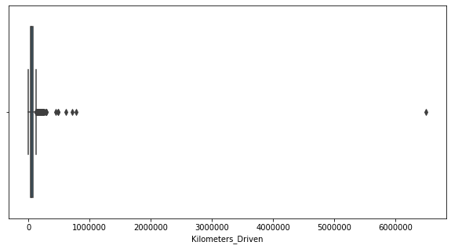

```python
plt.figure(figsize=(10,5))
sn.boxplot(data=train, x='Kilometers_Driven')
```

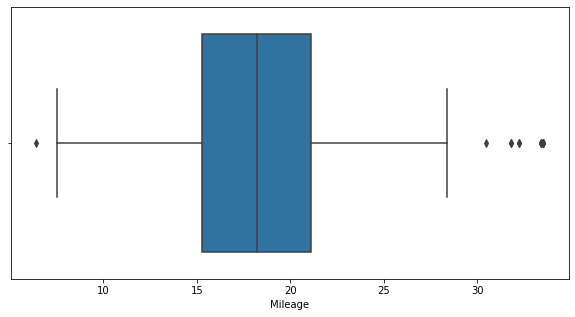

```python
plt.figure(figsize=(10,5))
sn.boxplot(data=train, x='Mileage')
```

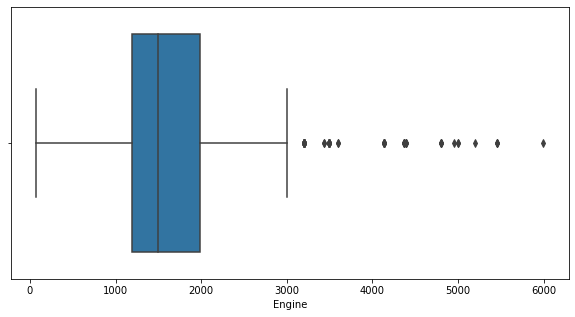

```python
plt.figure(figsize=(10,5))
sn.boxplot(data=train, x='Engine')
```

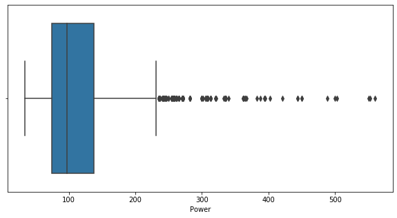

```python
plt.figure(figsize=(10,5))
sn.boxplot(data=train, x='Power')
```

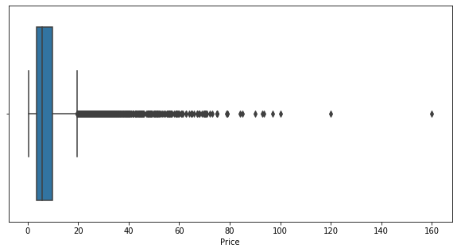

```python
plt.figure(figsize=(10,5))
sn.boxplot(data=train, x='Price')
```